# Regression and report generation

Niels Richard Hansen

February 4, 2016

# A practical exercise on using knitr

Solve this exercise using Markdown and knitr. Use [the code](https://nielsrhansen.github.io/courses/regression2016/Exercises/SAT.Rmd) that generated this document as a template.

From RStudio just click on ‘Knit HTML’ to get the result. Alternatively, you can run the following code.

```r
library(knitr)
library(markdown)
knit("SAT.Rmd")   ### Creates the Markdown file
markdownToHTML("SAT.md", "SAT.html") ### Creates the html file
browseURL(paste('file://', file.path(getwd(), 'SAT.html'), sep=''))
```

You can also read more about [using R and Markdown with RStudio](http://rmarkdown.rstudio.com).

The data set to consider in this exercise consists of mean verbal SAT scores for each of the 50 US states together with the percentage of students taking the test.

To help you get started we read in the data and construct a plot.

```r
sat <- read.table(
  "https://nielsrhansen.github.io/courses/regression2016/Data/SAT.txt",
  header = TRUE)
```

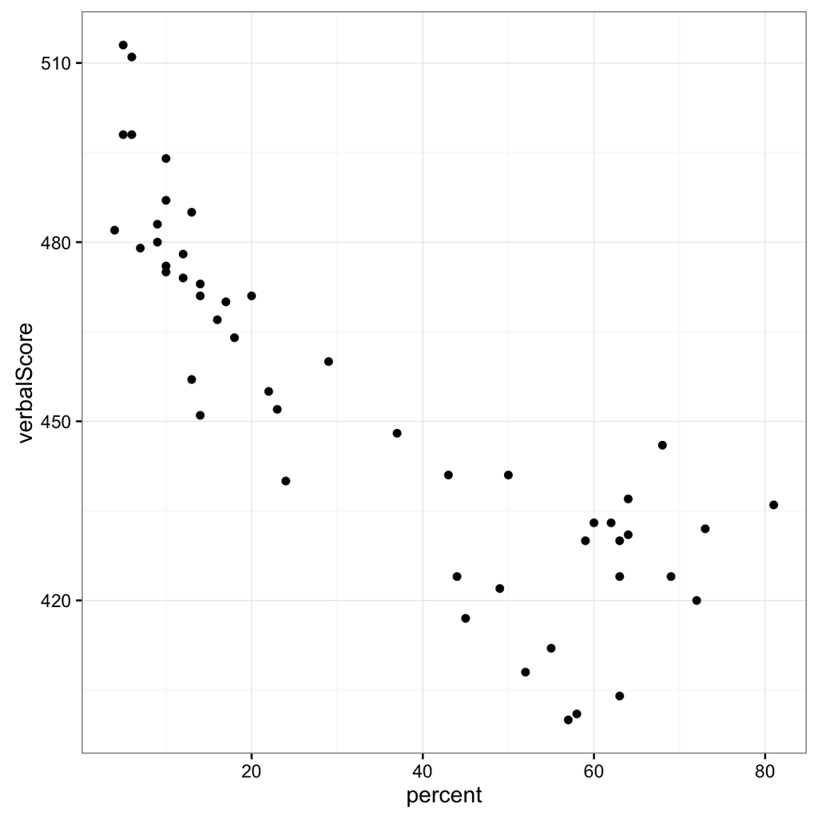

```r
library(ggplot2)
theme_set(theme_bw()) ## My choice of theme over the default.
qplot(percent, verbalScore, data = sat)
```

## Question 1

Fit a linear regression model with an intercept of the state SAT score as a function of percentage of students. Add the fitted line to the plot.

## Question 2

Fit a piecewise affine function with the “bend” at 50% of the students taking the test. How can you formally test the linearity assumption in Question 1 within this larger model?

*Hint: What you want to achieve in this question is to fit a linear model $\mathbf{Y} = \mathbf{X} \beta + \varepsilon$ where $\mathbf{X}$ is a matrix with 3 columns representing an intercept and two piecewise linear functions. You can, for instance, generate a basis using an `ifelse` construction. Try different bases. Is there anyone particularly suitable for testing the linearity assumption?*

## Question 3

Fit a natural cubic spline model with 4 knots. Use the `ns` function to generate a B-spline basis. How should you choose the placements of the knots? How can you formally test the linearity assumption within this larger model?

## Changing the output format

The default is to get an HTML file, which can be viewed in a browser. Occasionally, you might want to turn the result into pdf. This can be achieved i RStudio by selecting to knit to pdf. If you really want a nice report in pdf, it is better to integrate R with LaTeX instead of markdown.